# Project 1 - Reproducible Research

Stephany Michell Lobo Laguado

24/5/2021

```r
library(dplyr)
library(lubridate)
```

```r
library(ggplot2)
library(lattice)
```

## Loading an pre-processing data

```r
datos <- read.csv("./activity.csv", sep = ",", header = T)
str(datos)
```

```
## 'data.frame':    17568 obs. of  3 variables:
##  $ steps   : int  NA NA NA NA NA NA NA NA NA NA ...
##  $ date    : chr  "2012-10-01" "2012-10-01" "2012-10-01" "2012-10-01" ...
##  $ interval: int  0 5 10 15 20 25 30 35 40 45 ...
```

```r
summary(datos)
```

```
##      steps            date              interval
##  Min.   :  0.00   Length:17568       Min.   :   0.0
##  1st Qu.:  0.00   Class :character   1st Qu.: 588.8
##  Median :  0.00   Mode  :character   Median :1177.5
##  Mean   : 37.38                      Mean   :1177.5
##  3rd Qu.: 12.00                      3rd Qu.:1766.2
##  Max.   :806.00                      Max.   :2355.0
##  NA's   :2304
```

```r
head(datos)
```

```
##   steps       date interval
## 1    NA 2012-10-01        0
## 2    NA 2012-10-01        5
## 3    NA 2012-10-01       10
## 4    NA 2012-10-01       15
## 5    NA 2012-10-01       20
## 6    NA 2012-10-01       25
```

```r
datos$date <- ymd(datos$date)
```

## What is mean total number of steps taken per day?

1. Calculate the total number of steps taken per day.

```r
steps_day <- datos %>%
        group_by(date) %>%
        summarise(steps_day = sum(steps, na.rm = T),
                  na = mean(is.na(steps))) %>%
        print()
```

```
## # A tibble: 61 x 3
##    date       steps_day    na
##    <date>         <int> <dbl>
##  1 2012-10-01         0     1
##  2 2012-10-02       126     0
##  3 2012-10-03     11352     0
##  4 2012-10-04     12116     0
##  5 2012-10-05     13294     0
##  6 2012-10-06     15420     0
##  7 2012-10-07     11015     0
##  8 2012-10-08         0     1
##  9 2012-10-09     12811     0
## 10 2012-10-10      9900     0
## # ... with 51 more rows
```

2. If you do not understand the difference between a histogram and a barplot, research the difference between them. Make a histogram of the total number of steps taken each day.

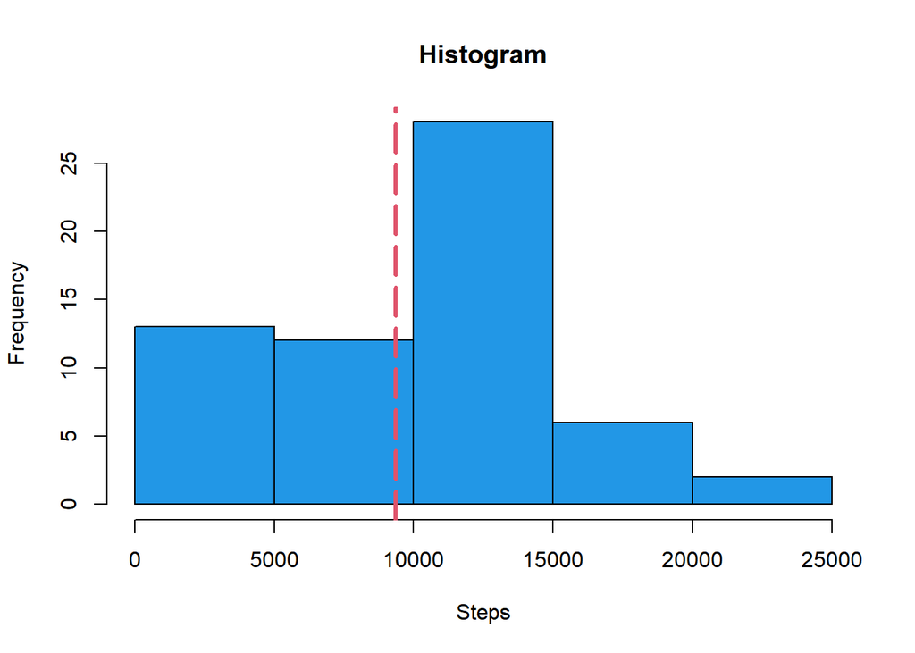

```r
hist(steps_day$steps_day, main = "Histogram", col = 4,
     xlab = "Steps")
abline(v = mean(steps_day$steps_day), lty = 5, lwd = 3, col = 2)
```

3. Calculate and report the mean and median of the total number of steps taken per day.

```r
mean_steps <- mean(steps_day$steps_day)
median_steps <- median(steps_day$steps_day)
mean_steps
```

```
## [1] 9354.23
```

```r
median_steps
```

```
## [1] 10395
```

The mean of the total number of the steps taken per day is 9354.2295082 and the median of the total number of the steps taken per day is 10395.

## What is the average daily activity pattern?

1. Make a time series plot (i.e. type = “l”) of the 5-minute interval (x-axis) and the average number of steps taken, averaged across all days (y-axis)

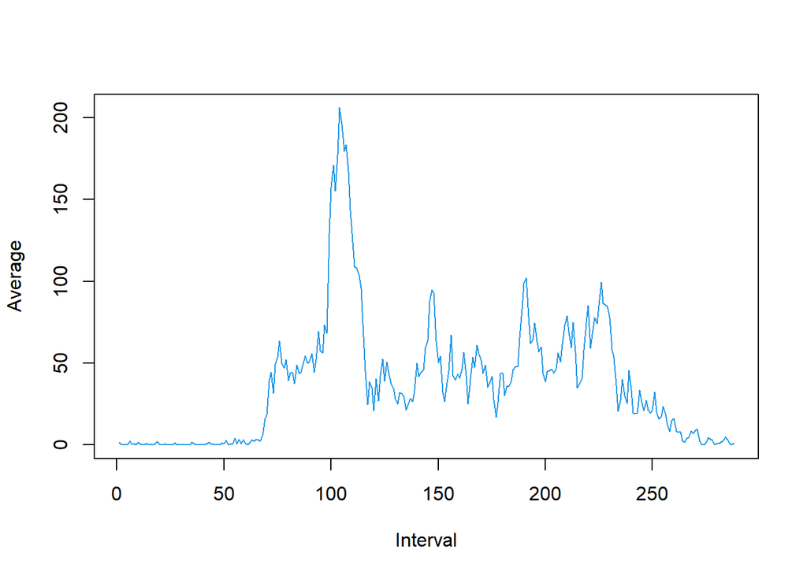

```r
patterns <- datos %>% group_by(interval) %>%
        summarise(average = mean(steps, na.rm = T))
plot(x = 1:288, y = patterns$average, type = "l", col = 4,
     xlab = "Interval", ylab = "Average")
```

2. Which 5-minute interval, on average across all the days in the dataset, contains the maximum number of steps?

```r
maxi <- filter(patterns, average == max(average))
```

The interval 835 contains the maximum number of steps, which is 206.1698113 on average across all the days in the dataset.

## Imputing missing values

1. Calculate and report the total number of missing values in the dataset.

```r
nas <- sum(is.na(datos$steps))
nas
```

```
## [1] 2304
```

```r
nas_per <- mean(is.na(datos$steps))
nas_per
```

```
## [1] 0.1311475
```

The total number of missing values in the dataset is 2304, which is the 13.1 % of the observations in the dataset.

2. Devise a strategy for filling in all of the missing values in the dataset. The strategy does not need to be sophisticated. For example, you could use the mean/median for that day, or the mean for that 5-minute interval, etc.

There is a lot of missing values in the dataset, so we could considerate replace them using the average per interval.

3. Create a new dataset that is equal to the original dataset but with the missing data filled in.

```r
no_nas <- rep(NA, nrow(datos))
for (i in 1:nrow(datos)) {
        if (is.na(datos[i,"steps"] == T)) {
                no_nas[i] <- filter(patterns, interval == datos[i,"interval"]) %>% select(average)
        }
        else{
                no_nas[i] <- datos[i,"steps"]
        }

}

no_nas <- as.numeric(no_nas)
new_data <- mutate(datos, steps_new = no_nas)
```

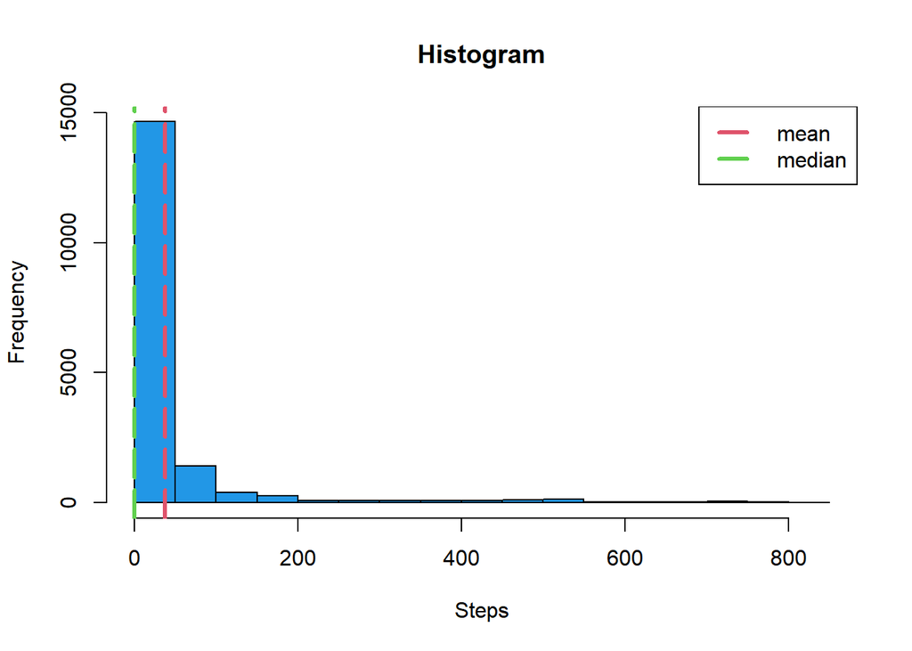

```r
hist(new_data$steps_new, main = "Histogram", col = 4,
     xlab = "Steps")
abline(v = mean(new_data$steps_new), lty = 5, lwd = 3, col = 2)
abline(v = median(new_data$steps_new), lty = 5, lwd = 3, col = 3)
legend("topright", legend = c("mean", "median"), col = c(2,3),
       lty = 5, lwd = 3)
```

## Are there differences in activity patterns between weekdays and weekends?

```r
weekends <- which(weekdays(as.Date(new_data$date)) == "Saturday" |
              weekdays(as.Date(new_data$date)) == "Sunday")
weekdays <- which(weekdays(as.Date(new_data$date)) != "Saturday" &
              weekdays(as.Date(new_data$date)) != "Sunday")
w <- rep(NA, nrow(new_data))
w[weekends] <- "weekend"
w[weekdays] <- "weekday"

new_data <- new_data %>%  mutate(day = w)
```

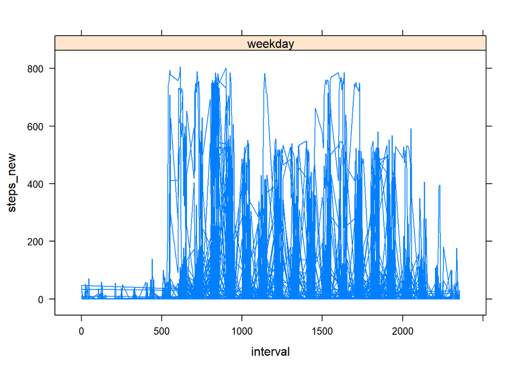

```r
xyplot(steps_new ~ interval | day, data = new_data, type = "l")
```